# S6_informe

## Modelos Probabilisticos

**Distribución binomial**

Una distribución binomial es una distribución donde esta asociada una probabilidad fija y un tamaño de muestra, el tamaño de muestra lo escogemos en este caso es 22 y la probabilidad es fija de 0.210 por que esa es la proporción de estudiantes que le gusta las clases virtuales.

```r
##Binomial; Supongamos que la variable "alumnos que les gusta las clases virtuales se distribuye Binomial"
ap<-table(P1$Apuntes)
ap
```

```
##
##   Ambos  Fisico Virtual
##      71      87      42
```

```r
x<-prop.table(table(P1$Apuntes))
p<-0.210
n<-22
#Si tenemos una muestra aleatoria de 22 estudiantes
#Hallar la probabilidad de que  de los 22 a 7 les gusten las clases virtuales
p1<-dbinom(7,n,p)
p1
```

```
## [1] 0.08949069
```

```r
##Hallar la probabilidad de que a mas de 5 les guste las clases virtuales
p2<-pbinom(5,n,p,lower.tail=FALSE)
p2
```

```
## [1] 0.3086075
```

[figure not shown]

```r
plot(dbinom(0:22,n,p),type="h",xlab="X",ylab="P(X=x)",main="Funcion de Probabilidad B(22,0.215)")
```

**Distribución Hipergeometrica**

Una distribución Hipergeométrica es cuando yo cuento con una población n en este caso la población es de 200 y en esa población tengo subconjuntos o subpoblaciones con cierta característica, en este caso por ejemplo tengo ciertos estudiantes que les gusta estudiar en la biblioteca, otra cantidad que les guste estudiar en la cafetería y otra cantidad que le gusta estudiar en su casa y otra en el parque. Si tengo 4 subgrupos cada una con un valor distinto entonces la hipergeométrica se trata de que si de esos 200 yo tomo una muestra n en este caso nuestra muestra es de 25 cuál es la probabilidad de que de esos 25 por ejemplo 15 les gusta estudiar en la biblioteca igual sucede si de esos 25 cuál es la probabilidad de que a 10 les gusta estudiar en la cafetería y así se sacamos mas probabilidades con la hipergeométrica.

```r
##Hipergeometrica; tomemos la variable "Zona de estudio"
H<-table(P1$Zona)
H
```

```
##
## Biblioteca  Cafeteria       Casa     Parque
##         54          7        137          2
```

```r
#Si tenemos una muestra aleatoria de 25 estudiantes
n<-25
k<-137
N<-sum(H)
```

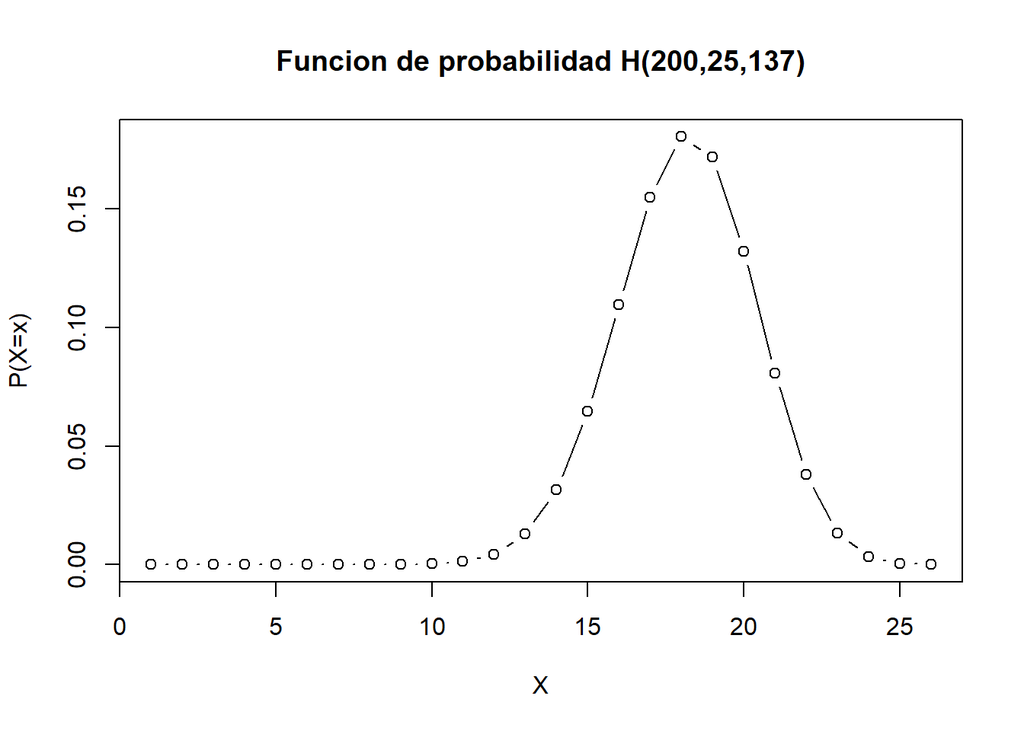

```r
plot(dhyper(0:25,n,N-n,k),type = "b",xlab="X",ylab="P(X=x)",main="Funcion de probabilidad H(200,25,137)")
```

```r
#Probabilidad de que 20 prefieran estudiar en casa
h1<-dhyper(20,n,N-n,k)
h1
```

```
## [1] 0.08067907
```

```r
##Probabilidad de que como máximo a 5 les guste estudiar en la biblioteca
k<-54
h2<-phyper(5,n,N-n,k)
h2
```

```
## [1] 0.280245
```

```r
##La cantidad esperada de estudiantes que les guste estudiar en la cafetería
k<-7

e<-n*k/N
e
```

```
## [1] 0.875
```

**Distribución Poisson**

La distribución Poisson, esta distribución de probabilidad se usan siempre usando solamente un parámetro que es el promedio o la taza en un intervalo de tiempo o en un intervalo de área o de superficie. En este caso calculamos el promedio de las horas que estudia un estudiante en un día, porque es la cantidad o la tasa que se estudia en un determinado tiempo, en este caso el tiempo está dado por un día. El promedio de las horas que estudia un estudiante en un día es 4.0875 ya con este parámetro podemos declarar las probabilidades.

```r
##Poisson: Supongamos que la tasa de horas de estudio de un estudiantes es de L por día

L<-mean(P1$Tiempo)
L
```

```
## [1] 4.0875
```

```r
##Probabilidad de dedicar 2 horas de estudio al día
p1<-dpois(2,L)
p1
```

```
## [1] 0.1401867
```

```r
##Probabilidad de dedicar mas de 6 horas de estudio en un día
p2<-ppois(6,L,lower.tail = FALSE)
p2
```

```
## [1] 0.119989
```

```r
##Probabilidad de estudiar menos de 6 horas en 2 días
L2<-2*L
p3<-ppois(5,L2)
p3
```

```
## [1] 0.1757261
```

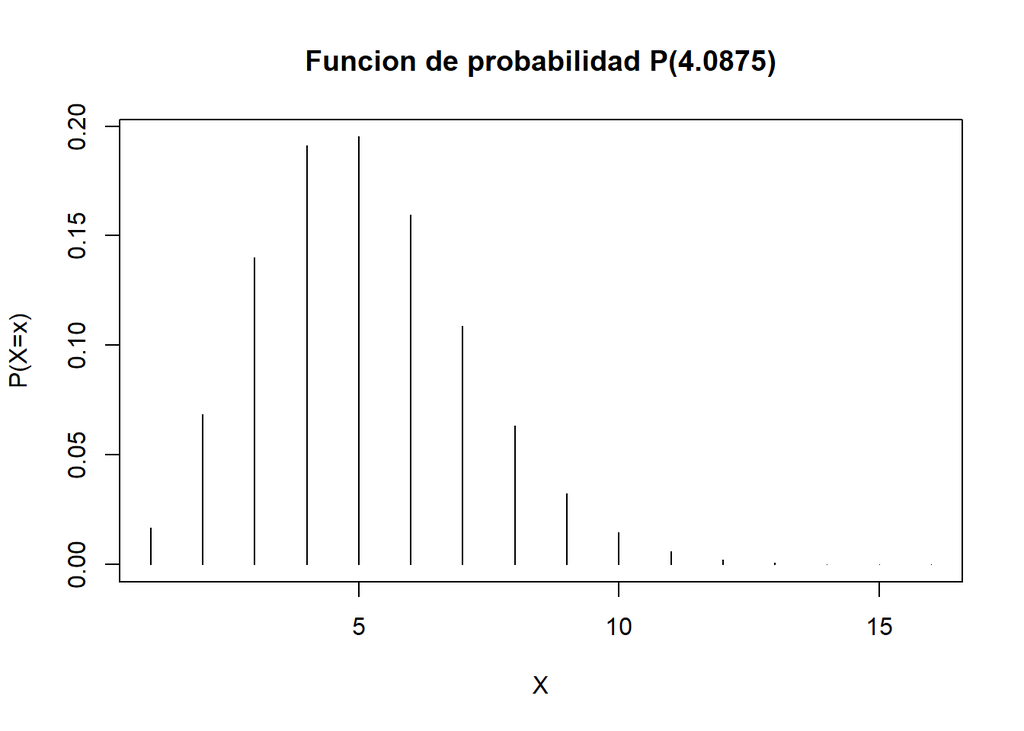

```r
plot(dpois(0:15,L),type = "h",xlab="X",ylab="P(X=x)",main="Funcion de probabilidad P(4.0875)")
```

**Distribución Normal**

La distribución normal, en este caso solamente vamos a suponer que el promedio de las notas se distribuye de manera normal, porque para demostrar que está variable se distribuye de manera normal tenemos que hacer una prueba que se llama Shapiro Wilk. Entonces vamos a suponer que el promedio de notas se distribuye de manera normal, tenemos que la nota promedio en este caso fue 14.99445 puntos y la desviación estándar 1.722291 ya con estos parámetros se empieza a declarar las probabilidades de notas por ejemplos la probabilidad de que un estudiante tenga menos de 12 puntos de promedio y así sucesivamente declaramos mas probabilidades.

[figure not shown]

```r
#Normal: Supongamos que la nota promedio de los estudiantes se distribuyen de manera normal

mu<-mean(P1$Promedio)
sig<-sd(P1$Promedio)
plot(dnorm(5:25,mu,sig),type = "h",xlab="X",ylab="P(X=x)",main="Funcion de probabilidad N(14.99, 2.01)")
```

```r
##Probabilidad de que un estudiante tenga menos de 12 puntos de promedio
N1<-pnorm(12,mu,sig)
N1
```

```
## [1] 0.04104874
```

```r
##Probabilidad de que un alumno tengas mas de 14 puntos de promedio
N2<-pnorm(14,mu,sig,lower.tail = FALSE)
N2
```

```
## [1] 0.7181652
```

```r
##Probabilidad de que tenga nota entre 13 y 19 puntos de promedio
N3<-pnorm(19,mu,sig)-pnorm(13,mu,sig)
N3
```

```
## [1] 0.8665554
```

# Bibliografia

[*Ramos (2020) determina si “las técnicas de estudio, motivación, hábitos de estudio y el rendimiento académico se asocian al puntaje obtenido en la ENAM”(p.1).*](http://repositorio.unsa.edu.pe/bitstream/handle/UNSA/10895/MCrasuj.pdf?sequence=1)

[*Freiberg Hoffmann, A., Ledesma, R., & Fernández Liporace, M. (2017). Estilos y estrategias de aprendizaje en estudiantes universitarios de Buenos Aires. Revista de Psicología (PUCP).*](http://www.scielo.org.pe/scielo.php?script=sci_arttext&pid=S0254-92472017000200005)

[*Murcia Valenzuela, L. C., Rodriguez Franco, A. S., & Sanchez Rodriguez, D. L. (2017). Métodos de aprendizaje de estudiantes de la Universidad de Ciencias Aplicadas y Ambientales u.d.c.a que presentaron el examen de ciencias básicas en los periodos de 2016–1 a 2017–1. Universidad de ciencias aplicadas y ambientales U.D.C.A.*](https://repository.udca.edu.co/bitstream/handle/11158/846/Metodos%20de%20aprendizaje%20.pdf?sequence=1&isAllowed=)